# Week 9 Case Study

Tyson Brost

March 15, 2022

```r
# Use this R-Chunk to import all your datasets!
sales_dat <- read.csv("https://byuistats.github.io/M335/data/sales.csv")
```

## Background

Read in the data from https://byuistats.github.io/M335/data/sales.csv and format it for visualization and analysis.

The data are for businesses in the mountain time zone make sure you read in times correctly.

This is point of sale (pos) data, so you will need to use library(lubridate) to create the correct time aggregations.

Check the data for any inaccuracies.

Help your boss understand which business is the best investment through visualizations. Provide an understanding and recommendation for hours of operation. We don’t have employee numbers, but sales traffic can help. Provide some visualizations on customer traffic. Provide a final comparison of the six companies and a final recommendation.

#### Pander doesn’t display properly in the .md. use the html for best viewing

## Data Wrangling

```r
# Use this R-Chunk to clean & wrangle your data!
sales_dat$Time <- ymd_hms(sales_dat$Time, tz = "MST")
sales_dat$Time <- ceiling_date(sales_dat$Time, "hour")
sales_dat$hour <- format(as.POSIXct(sales_dat$Time), format = "%H")
sales_dat$day <- weekdays(as.POSIXct(sales_dat$Time), abbreviate = F)
sales_dat$week <- week(as.POSIXct(sales_dat$Time))
sales_dat$month<- month(as.POSIXct(sales_dat$Time))

sales_dat$day <- fct_inorder(sales_dat$day)
sales_dat<-sales_dat %>% filter(Name != "Missing", month != 4)
```

## Data Visualization

### Monthly

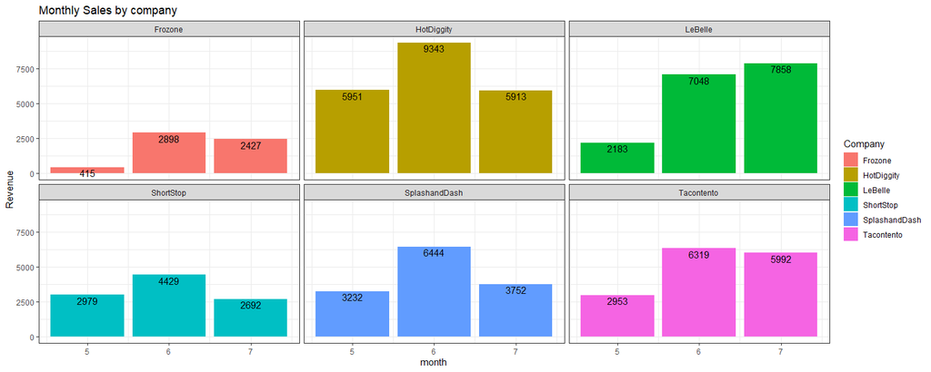

```r
# Use this R-Chunk to plot & visualize your data!



sales_sum_Week <- sales_dat %>%
  group_by(Name, week, day) %>%
  summarise(Rev = sum(Amount))
sales_sum_Week$day <- case_when(
  sales_sum_Week$day == "Monday" ~ 0,
  sales_sum_Week$day == "Tuesday" ~ 1,
  sales_sum_Week$day == "Wednesday" ~ 2,
  sales_sum_Week$day == "Thursday" ~ 3,
  sales_sum_Week$day == "Friday" ~ 4,
  sales_sum_Week$day == "Saturday" ~ 5,
  sales_sum_Week$day == "Sunday" ~ 6)
sales_sum_Week$week_d <- sales_sum_Week$week + sales_sum_Week$day/7

sales_sum_Week_avg <- sales_sum_Week %>% group_by(Name, week) %>% summarise(Rev_avg = mean(Rev))

sales_sum <- sales_dat %>%
  group_by(Name, day, hour) %>%
  summarise(Rev = sum(Amount))
sales_sum_D <- sales_dat %>%
  group_by(Name, day) %>%
  summarise(Rev_sum = sum(Amount))
sales_sum_W <- sales_dat %>%
  group_by(Name) %>%
  summarise(Rev_sum = sum(Amount))
sales_sum_W$day = "Sunday"


sales_sum_M <- sales_dat %>%
  group_by(Name, month) %>%
  summarise(Rev = sum(Amount))

#levels(sales_sum$day)

#labels_week <- c("Monday \n 4","Tuesday","Wednesday", "Thursday", "Friday", "Saturday", "Sunday")


# Monthly:

ggplot() +
  geom_col(aes(x=month, y=Rev, fill=Name), position="dodge" ,  data=sales_sum_M)+
  #geom_hline(aes(yintercept = Mean7day), bake10M)+
  geom_text(
    aes(label = paste(round(Rev,0)), x= month ,y = round(Rev,0)),vjust=1.2,
    position = position_dodge(),
    vjust = 0, sales_sum_M)+
  facet_wrap(~Name)+
  labs(fill = "Company", title= "Monthly Sales by company")+
  ylab("Revenue")+theme_bw()
```

```r
sales_sum_M %>%
    pivot_wider(names_from = month, values_from = Rev) %>% mutate(Total = `5` + `6` +`7`) %>% pander(caption= "Monthly total Sales by Company")
```

Monthly total Sales by Company

| Name | 5 | 6 | 7 | Total |
| --- | --- | --- | --- | --- |
| Frozone | 415.2 | 2898 | 2427 | 5741 |
| HotDiggity | 5951 | 9343 | 5913 | 21207 |
| LeBelle | 2183 | 7048 | 7858 | 17089 |
| ShortStop | 2979 | 4429 | 2692 | 10101 |
| SplashandDash | 3232 | 6444 | 3752 | 13428 |
| Tacontento | 2953 | 6319 | 5992 | 15264 |